# Risk Factor Analysis

## Outcome Variable

**Outcome Variable:** ever_stunted

## Predictor Variables

**Intervention Variable:** brthmon

**Adjustment Set:**

unadjusted

## Stratifying Variables

The analysis was stratified on these variable(s):

- agecat
- studyid
- country

## Data Summary

| agecat | studyid | country | A | n | nA | nAY0 | nAY1 |
| --- | --- | --- | --- | --- | --- | --- | --- |
| 3 months | ki0047075b-MAL-ED | BANGLADESH | 1 | 265 | 21 | 15 | 6 |
| 3 months | ki0047075b-MAL-ED | BANGLADESH | 2 | 265 | 25 | 16 | 9 |
| 3 months | ki0047075b-MAL-ED | BANGLADESH | 3 | 265 | 25 | 15 | 10 |
| 3 months | ki0047075b-MAL-ED | BANGLADESH | 4 | 265 | 22 | 22 | 0 |
| 3 months | ki0047075b-MAL-ED | BANGLADESH | 5 | 265 | 22 | 12 | 10 |
| 3 months | ki0047075b-MAL-ED | BANGLADESH | 6 | 265 | 11 | 7 | 4 |
| 3 months | ki0047075b-MAL-ED | BANGLADESH | 7 | 265 | 20 | 15 | 5 |
| 3 months | ki0047075b-MAL-ED | BANGLADESH | 8 | 265 | 26 | 16 | 10 |
| 3 months | ki0047075b-MAL-ED | BANGLADESH | 9 | 265 | 23 | 18 | 5 |
| 3 months | ki0047075b-MAL-ED | BANGLADESH | 10 | 265 | 25 | 17 | 8 |
| 3 months | ki0047075b-MAL-ED | BANGLADESH | 11 | 265 | 17 | 12 | 5 |
| 3 months | ki0047075b-MAL-ED | BANGLADESH | 12 | 265 | 28 | 22 | 6 |
| 3 months | ki0047075b-MAL-ED | BRAZIL | 1 | 233 | 15 | 13 | 2 |
| 3 months | ki0047075b-MAL-ED | BRAZIL | 2 | 233 | 25 | 21 | 4 |
| 3 months | ki0047075b-MAL-ED | BRAZIL | 3 | 233 | 20 | 16 | 4 |
| 3 months | ki0047075b-MAL-ED | BRAZIL | 4 | 233 | 12 | 11 | 1 |
| 3 months | ki0047075b-MAL-ED | BRAZIL | 5 | 233 | 23 | 19 | 4 |
| 3 months | ki0047075b-MAL-ED | BRAZIL | 6 | 233 | 9 | 6 | 3 |
| 3 months | ki0047075b-MAL-ED | BRAZIL | 7 | 233 | 18 | 14 | 4 |
| 3 months | ki0047075b-MAL-ED | BRAZIL | 8 | 233 | 21 | 18 | 3 |
| 3 months | ki0047075b-MAL-ED | BRAZIL | 9 | 233 | 32 | 25 | 7 |
| 3 months | ki0047075b-MAL-ED | BRAZIL | 10 | 233 | 21 | 19 | 2 |
| 3 months | ki0047075b-MAL-ED | BRAZIL | 11 | 233 | 22 | 22 | 0 |
| 3 months | ki0047075b-MAL-ED | BRAZIL | 12 | 233 | 15 | 11 | 4 |
| 3 months | ki0047075b-MAL-ED | INDIA | 1 | 251 | 20 | 12 | 8 |
| 3 months | ki0047075b-MAL-ED | INDIA | 2 | 251 | 21 | 21 | 0 |
| 3 months | ki0047075b-MAL-ED | INDIA | 3 | 251 | 23 | 17 | 6 |
| 3 months | ki0047075b-MAL-ED | INDIA | 4 | 251 | 17 | 12 | 5 |
| 3 months | ki0047075b-MAL-ED | INDIA | 5 | 251 | 8 | 7 | 1 |
| 3 months | ki0047075b-MAL-ED | INDIA | 6 | 251 | 20 | 18 | 2 |

[output cut: 1350 more lines]

The following strata were considered:

- agecat: 12 months, studyid: ki0047075b-MAL-ED, country: BANGLADESH
- agecat: 12 months, studyid: ki0047075b-MAL-ED, country: BRAZIL
- agecat: 12 months, studyid: ki0047075b-MAL-ED, country: INDIA
- agecat: 12 months, studyid: ki0047075b-MAL-ED, country: NEPAL
- agecat: 12 months, studyid: ki0047075b-MAL-ED, country: PERU
- agecat: 12 months, studyid: ki0047075b-MAL-ED, country: SOUTH AFRICA
- agecat: 12 months, studyid: ki0047075b-MAL-ED, country: TANZANIA, UNITED REPUBLIC OF
- agecat: 12 months, studyid: ki1000108-CMC-V-BCS-2002, country: INDIA
- agecat: 12 months, studyid: ki1000108-IRC, country: INDIA
- agecat: 12 months, studyid: ki1000109-EE, country: PAKISTAN
- agecat: 12 months, studyid: ki1000109-ResPak, country: PAKISTAN
- agecat: 12 months, studyid: ki1000304b-SAS-FoodSuppl, country: INDIA
- agecat: 12 months, studyid: ki1017093-NIH-Birth, country: BANGLADESH
- agecat: 12 months, studyid: ki1066203-TanzaniaChild2, country: TANZANIA, UNITED REPUBLIC OF
- agecat: 12 months, studyid: ki1101329-Keneba, country: GAMBIA
- agecat: 12 months, studyid: ki1112895-Guatemala BSC, country: GUATEMALA
- agecat: 12 months, studyid: ki1113344-GMS-Nepal, country: NEPAL
- agecat: 12 months, studyid: ki1114097-CMIN, country: BANGLADESH
- agecat: 12 months, studyid: ki1114097-CMIN, country: BRAZIL
- agecat: 12 months, studyid: ki1114097-CMIN, country: GUINEA-BISSAU
- agecat: 12 months, studyid: ki1114097-CMIN, country: PERU
- agecat: 12 months, studyid: ki1114097-CONTENT, country: PERU
- agecat: 12 months, studyid: ki1126311-ZVITAMBO, country: ZIMBABWE
- agecat: 12 months, studyid: ki1148112-LCNI-5, country: MALAWI
- agecat: 18 months, studyid: ki0047075b-MAL-ED, country: BANGLADESH
- agecat: 18 months, studyid: ki0047075b-MAL-ED, country: BRAZIL
- agecat: 18 months, studyid: ki0047075b-MAL-ED, country: INDIA
- agecat: 18 months, studyid: ki0047075b-MAL-ED, country: NEPAL
- agecat: 18 months, studyid: ki0047075b-MAL-ED, country: PERU
- agecat: 18 months, studyid: ki0047075b-MAL-ED, country: SOUTH AFRICA
- agecat: 18 months, studyid: ki0047075b-MAL-ED, country: TANZANIA, UNITED REPUBLIC OF
- agecat: 18 months, studyid: ki1000108-CMC-V-BCS-2002, country: INDIA
- agecat: 18 months, studyid: ki1000108-IRC, country: INDIA
- agecat: 18 months, studyid: ki1000109-EE, country: PAKISTAN
- agecat: 18 months, studyid: ki1000109-ResPak, country: PAKISTAN
- agecat: 18 months, studyid: ki1000304b-SAS-FoodSuppl, country: INDIA
- agecat: 18 months, studyid: ki1017093-NIH-Birth, country: BANGLADESH
- agecat: 18 months, studyid: ki1066203-TanzaniaChild2, country: TANZANIA, UNITED REPUBLIC OF
- agecat: 18 months, studyid: ki1101329-Keneba, country: GAMBIA
- agecat: 18 months, studyid: ki1112895-Guatemala BSC, country: GUATEMALA
- agecat: 18 months, studyid: ki1113344-GMS-Nepal, country: NEPAL
- agecat: 18 months, studyid: ki1114097-CMIN, country: BANGLADESH
- agecat: 18 months, studyid: ki1114097-CMIN, country: BRAZIL
- agecat: 18 months, studyid: ki1114097-CMIN, country: GUINEA-BISSAU
- agecat: 18 months, studyid: ki1114097-CMIN, country: PERU
- agecat: 18 months, studyid: ki1114097-CONTENT, country: PERU
- agecat: 18 months, studyid: ki1126311-ZVITAMBO, country: ZIMBABWE
- agecat: 18 months, studyid: ki1148112-LCNI-5, country: MALAWI
- agecat: 24 months, studyid: ki0047075b-MAL-ED, country: BANGLADESH
- agecat: 24 months, studyid: ki0047075b-MAL-ED, country: BRAZIL
- agecat: 24 months, studyid: ki0047075b-MAL-ED, country: INDIA
- agecat: 24 months, studyid: ki0047075b-MAL-ED, country: NEPAL
- agecat: 24 months, studyid: ki0047075b-MAL-ED, country: PERU
- agecat: 24 months, studyid: ki0047075b-MAL-ED, country: SOUTH AFRICA
- agecat: 24 months, studyid: ki0047075b-MAL-ED, country: TANZANIA, UNITED REPUBLIC OF
- agecat: 24 months, studyid: ki1000108-CMC-V-BCS-2002, country: INDIA
- agecat: 24 months, studyid: ki1000108-IRC, country: INDIA
- agecat: 24 months, studyid: ki1000109-EE, country: PAKISTAN
- agecat: 24 months, studyid: ki1000304b-SAS-FoodSuppl, country: INDIA
- agecat: 24 months, studyid: ki1017093-NIH-Birth, country: BANGLADESH
- agecat: 24 months, studyid: ki1066203-TanzaniaChild2, country: TANZANIA, UNITED REPUBLIC OF
- agecat: 24 months, studyid: ki1101329-Keneba, country: GAMBIA
- agecat: 24 months, studyid: ki1113344-GMS-Nepal, country: NEPAL
- agecat: 24 months, studyid: ki1114097-CMIN, country: BANGLADESH
- agecat: 24 months, studyid: ki1114097-CMIN, country: BRAZIL
- agecat: 24 months, studyid: ki1114097-CMIN, country: GUINEA-BISSAU
- agecat: 24 months, studyid: ki1114097-CMIN, country: PERU
- agecat: 24 months, studyid: ki1114097-CONTENT, country: PERU
- agecat: 24 months, studyid: ki1126311-ZVITAMBO, country: ZIMBABWE
- agecat: 24 months, studyid: ki1148112-LCNI-5, country: MALAWI
- agecat: 3 months, studyid: ki0047075b-MAL-ED, country: BANGLADESH
- agecat: 3 months, studyid: ki0047075b-MAL-ED, country: BRAZIL
- agecat: 3 months, studyid: ki0047075b-MAL-ED, country: INDIA
- agecat: 3 months, studyid: ki0047075b-MAL-ED, country: NEPAL
- agecat: 3 months, studyid: ki0047075b-MAL-ED, country: PERU
- agecat: 3 months, studyid: ki0047075b-MAL-ED, country: SOUTH AFRICA
- agecat: 3 months, studyid: ki0047075b-MAL-ED, country: TANZANIA, UNITED REPUBLIC OF
- agecat: 3 months, studyid: ki1000108-CMC-V-BCS-2002, country: INDIA
- agecat: 3 months, studyid: ki1000108-IRC, country: INDIA
- agecat: 3 months, studyid: ki1000109-EE, country: PAKISTAN
- agecat: 3 months, studyid: ki1000109-ResPak, country: PAKISTAN
- agecat: 3 months, studyid: ki1017093-NIH-Birth, country: BANGLADESH
- agecat: 3 months, studyid: ki1066203-TanzaniaChild2, country: TANZANIA, UNITED REPUBLIC OF
- agecat: 3 months, studyid: ki1101329-Keneba, country: GAMBIA
- agecat: 3 months, studyid: ki1113344-GMS-Nepal, country: NEPAL
- agecat: 3 months, studyid: ki1114097-CMIN, country: BANGLADESH
- agecat: 3 months, studyid: ki1114097-CMIN, country: BRAZIL
- agecat: 3 months, studyid: ki1114097-CMIN, country: GUINEA-BISSAU
- agecat: 3 months, studyid: ki1114097-CMIN, country: PERU
- agecat: 3 months, studyid: ki1114097-CONTENT, country: PERU
- agecat: 3 months, studyid: ki1126311-ZVITAMBO, country: ZIMBABWE
- agecat: 6 months, studyid: ki0047075b-MAL-ED, country: BANGLADESH
- agecat: 6 months, studyid: ki0047075b-MAL-ED, country: BRAZIL
- agecat: 6 months, studyid: ki0047075b-MAL-ED, country: INDIA
- agecat: 6 months, studyid: ki0047075b-MAL-ED, country: NEPAL
- agecat: 6 months, studyid: ki0047075b-MAL-ED, country: PERU
- agecat: 6 months, studyid: ki0047075b-MAL-ED, country: SOUTH AFRICA
- agecat: 6 months, studyid: ki0047075b-MAL-ED, country: TANZANIA, UNITED REPUBLIC OF
- agecat: 6 months, studyid: ki1000108-CMC-V-BCS-2002, country: INDIA
- agecat: 6 months, studyid: ki1000108-IRC, country: INDIA
- agecat: 6 months, studyid: ki1000109-EE, country: PAKISTAN
- agecat: 6 months, studyid: ki1000109-ResPak, country: PAKISTAN
- agecat: 6 months, studyid: ki1000304b-SAS-FoodSuppl, country: INDIA
- agecat: 6 months, studyid: ki1017093-NIH-Birth, country: BANGLADESH
- agecat: 6 months, studyid: ki1066203-TanzaniaChild2, country: TANZANIA, UNITED REPUBLIC OF
- agecat: 6 months, studyid: ki1101329-Keneba, country: GAMBIA
- agecat: 6 months, studyid: ki1112895-Guatemala BSC, country: GUATEMALA
- agecat: 6 months, studyid: ki1113344-GMS-Nepal, country: NEPAL
- agecat: 6 months, studyid: ki1114097-CMIN, country: BANGLADESH
- agecat: 6 months, studyid: ki1114097-CMIN, country: BRAZIL
- agecat: 6 months, studyid: ki1114097-CMIN, country: GUINEA-BISSAU
- agecat: 6 months, studyid: ki1114097-CMIN, country: PERU
- agecat: 6 months, studyid: ki1114097-CONTENT, country: PERU
- agecat: 6 months, studyid: ki1126311-ZVITAMBO, country: ZIMBABWE
- agecat: 6 months, studyid: ki1148112-LCNI-5, country: MALAWI

### Dropped Strata

Some strata were dropped due to rare outcomes:

- agecat: 3 months, studyid: ki0047075b-MAL-ED, country: BANGLADESH
- agecat: 3 months, studyid: ki0047075b-MAL-ED, country: BRAZIL
- agecat: 3 months, studyid: ki0047075b-MAL-ED, country: INDIA
- agecat: 3 months, studyid: ki0047075b-MAL-ED, country: NEPAL
- agecat: 3 months, studyid: ki0047075b-MAL-ED, country: PERU
- agecat: 3 months, studyid: ki0047075b-MAL-ED, country: SOUTH AFRICA
- agecat: 3 months, studyid: ki0047075b-MAL-ED, country: TANZANIA, UNITED REPUBLIC OF
- agecat: 3 months, studyid: ki1000108-CMC-V-BCS-2002, country: INDIA
- agecat: 3 months, studyid: ki1000109-EE, country: PAKISTAN
- agecat: 3 months, studyid: ki1000109-ResPak, country: PAKISTAN
- agecat: 3 months, studyid: ki1113344-GMS-Nepal, country: NEPAL
- agecat: 3 months, studyid: ki1114097-CMIN, country: BANGLADESH
- agecat: 3 months, studyid: ki1114097-CMIN, country: BRAZIL
- agecat: 3 months, studyid: ki1114097-CMIN, country: GUINEA-BISSAU
- agecat: 3 months, studyid: ki1114097-CMIN, country: PERU
- agecat: 3 months, studyid: ki1114097-CONTENT, country: PERU
- agecat: 6 months, studyid: ki0047075b-MAL-ED, country: BANGLADESH
- agecat: 6 months, studyid: ki0047075b-MAL-ED, country: BRAZIL
- agecat: 6 months, studyid: ki0047075b-MAL-ED, country: INDIA
- agecat: 6 months, studyid: ki0047075b-MAL-ED, country: NEPAL
- agecat: 6 months, studyid: ki0047075b-MAL-ED, country: PERU
- agecat: 6 months, studyid: ki0047075b-MAL-ED, country: SOUTH AFRICA
- agecat: 6 months, studyid: ki0047075b-MAL-ED, country: TANZANIA, UNITED REPUBLIC OF
- agecat: 6 months, studyid: ki1000109-EE, country: PAKISTAN
- agecat: 6 months, studyid: ki1000109-ResPak, country: PAKISTAN
- agecat: 6 months, studyid: ki1000304b-SAS-FoodSuppl, country: INDIA
- agecat: 6 months, studyid: ki1112895-Guatemala BSC, country: GUATEMALA
- agecat: 6 months, studyid: ki1113344-GMS-Nepal, country: NEPAL
- agecat: 6 months, studyid: ki1114097-CMIN, country: BANGLADESH
- agecat: 6 months, studyid: ki1114097-CMIN, country: BRAZIL
- agecat: 6 months, studyid: ki1114097-CMIN, country: GUINEA-BISSAU
- agecat: 6 months, studyid: ki1114097-CMIN, country: PERU
- agecat: 6 months, studyid: ki1114097-CONTENT, country: PERU
- agecat: 6 months, studyid: ki1148112-LCNI-5, country: MALAWI
- agecat: 12 months, studyid: ki0047075b-MAL-ED, country: BANGLADESH
- agecat: 12 months, studyid: ki0047075b-MAL-ED, country: BRAZIL
- agecat: 12 months, studyid: ki0047075b-MAL-ED, country: INDIA
- agecat: 12 months, studyid: ki0047075b-MAL-ED, country: NEPAL
- agecat: 12 months, studyid: ki0047075b-MAL-ED, country: SOUTH AFRICA
- agecat: 12 months, studyid: ki0047075b-MAL-ED, country: TANZANIA, UNITED REPUBLIC OF
- agecat: 12 months, studyid: ki1000108-CMC-V-BCS-2002, country: INDIA
- agecat: 12 months, studyid: ki1000109-EE, country: PAKISTAN
- agecat: 12 months, studyid: ki1000109-ResPak, country: PAKISTAN
- agecat: 12 months, studyid: ki1000304b-SAS-FoodSuppl, country: INDIA
- agecat: 12 months, studyid: ki1113344-GMS-Nepal, country: NEPAL
- agecat: 12 months, studyid: ki1114097-CMIN, country: BANGLADESH
- agecat: 12 months, studyid: ki1114097-CMIN, country: BRAZIL
- agecat: 12 months, studyid: ki1114097-CONTENT, country: PERU
- agecat: 18 months, studyid: ki0047075b-MAL-ED, country: BANGLADESH
- agecat: 18 months, studyid: ki0047075b-MAL-ED, country: BRAZIL
- agecat: 18 months, studyid: ki0047075b-MAL-ED, country: INDIA
- agecat: 18 months, studyid: ki0047075b-MAL-ED, country: NEPAL
- agecat: 18 months, studyid: ki0047075b-MAL-ED, country: PERU
- agecat: 18 months, studyid: ki0047075b-MAL-ED, country: SOUTH AFRICA
- agecat: 18 months, studyid: ki0047075b-MAL-ED, country: TANZANIA, UNITED REPUBLIC OF
- agecat: 18 months, studyid: ki1000108-CMC-V-BCS-2002, country: INDIA
- agecat: 18 months, studyid: ki1000109-EE, country: PAKISTAN
- agecat: 18 months, studyid: ki1000109-ResPak, country: PAKISTAN
- agecat: 18 months, studyid: ki1000304b-SAS-FoodSuppl, country: INDIA
- agecat: 18 months, studyid: ki1112895-Guatemala BSC, country: GUATEMALA
- agecat: 18 months, studyid: ki1113344-GMS-Nepal, country: NEPAL
- agecat: 18 months, studyid: ki1114097-CMIN, country: BANGLADESH
- agecat: 18 months, studyid: ki1114097-CMIN, country: BRAZIL
- agecat: 18 months, studyid: ki1114097-CONTENT, country: PERU
- agecat: 24 months, studyid: ki0047075b-MAL-ED, country: BANGLADESH
- agecat: 24 months, studyid: ki0047075b-MAL-ED, country: BRAZIL
- agecat: 24 months, studyid: ki0047075b-MAL-ED, country: INDIA
- agecat: 24 months, studyid: ki0047075b-MAL-ED, country: NEPAL
- agecat: 24 months, studyid: ki0047075b-MAL-ED, country: PERU
- agecat: 24 months, studyid: ki0047075b-MAL-ED, country: SOUTH AFRICA
- agecat: 24 months, studyid: ki0047075b-MAL-ED, country: TANZANIA, UNITED REPUBLIC OF
- agecat: 24 months, studyid: ki1000108-CMC-V-BCS-2002, country: INDIA
- agecat: 24 months, studyid: ki1000108-IRC, country: INDIA
- agecat: 24 months, studyid: ki1000109-EE, country: PAKISTAN
- agecat: 24 months, studyid: ki1000304b-SAS-FoodSuppl, country: INDIA
- agecat: 24 months, studyid: ki1113344-GMS-Nepal, country: NEPAL
- agecat: 24 months, studyid: ki1114097-CMIN, country: BANGLADESH
- agecat: 24 months, studyid: ki1114097-CMIN, country: BRAZIL
- agecat: 24 months, studyid: ki1114097-CONTENT, country: PERU

## Methods Detail

We’re interested in the causal parameters $E[Y_a]$ for all values of $a \in \mathcal{A}$. These parameters represent the mean outcome if, possibly contrary to fact, we intervened to set all units to have $A=a$. Under the randomization and positivity assumptions, these are identified by the statistical parameters $\psi_a=E_W[E_{Y|A,W}(Y|A=a,W)]$. In addition, we’re interested in the mean of $Y$, $E[Y]$ under no intervention (the observed mean). We will estimate these parameters by using SuperLearner to fit the relevant likelihood factors – $E_{Y|A,W}(Y|A=a,W)$ and $p(A=a|W)$, and then updating our likelihood fit using a joint TMLE.

For unadjusted analyses ($W=\{\}$), initial likelihoods were estimated using Lrnr_glm to estimate the simple $E(Y|A)$ and Lrnr_mean to estimate $p(A)$. For adjusted analyses, a small library containing Lrnr_glmnet, Lrnr_xgboost, and Lrnr_mean was used.

Having estimated these parameters, we will then use the delta method to estimate relative risks and attributable risks relative to a prespecified baseline level of $A$.

# Results Detail

## Results Plots

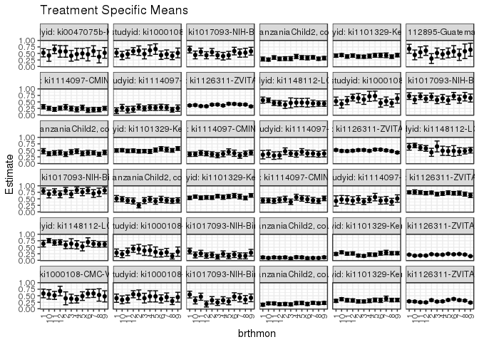

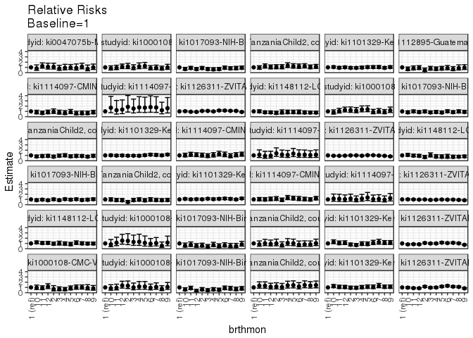

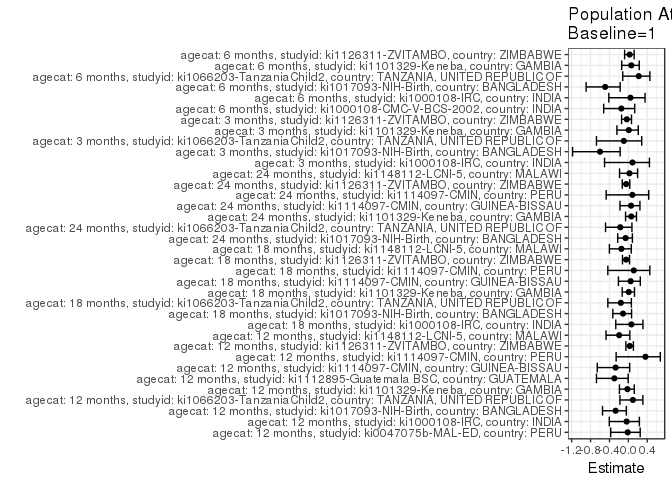

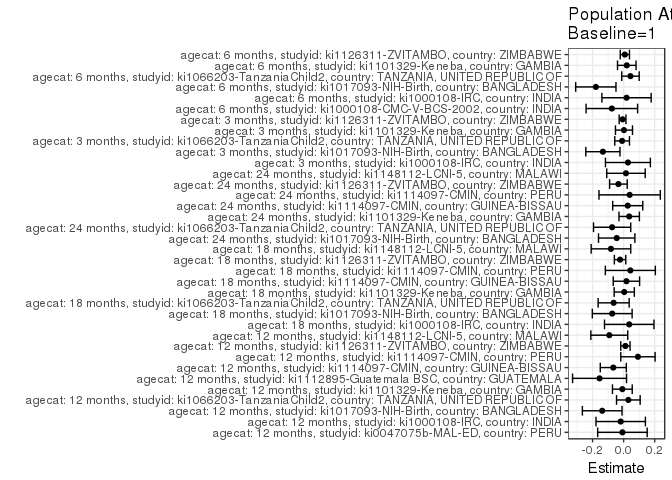

## Results Table

### Parameter: TSM

| agecat | studyid | country | intervention_level | baseline_level | estimate | ci_lower | ci_upper |
| --- | --- | --- | --- | --- | --- | --- | --- |
| 3 months | ki1000108-IRC | INDIA | 1 | NA | 0.2894737 | 0.1451023 | 0.4338451 |
| 3 months | ki1000108-IRC | INDIA | 2 | NA | 0.4285714 | 0.2450478 | 0.6120950 |
| 3 months | ki1000108-IRC | INDIA | 3 | NA | 0.3703704 | 0.1879988 | 0.5527420 |
| 3 months | ki1000108-IRC | INDIA | 4 | NA | 0.3809524 | 0.1729989 | 0.5889058 |
| 3 months | ki1000108-IRC | INDIA | 5 | NA | 0.3181818 | 0.1233145 | 0.5130491 |
| 3 months | ki1000108-IRC | INDIA | 6 | NA | 0.2702703 | 0.1269995 | 0.4135411 |
| 3 months | ki1000108-IRC | INDIA | 7 | NA | 0.3055556 | 0.1548980 | 0.4562131 |
| 3 months | ki1000108-IRC | INDIA | 8 | NA | 0.1590909 | 0.0508854 | 0.2672964 |
| 3 months | ki1000108-IRC | INDIA | 9 | NA | 0.3333333 | 0.1553045 | 0.5113621 |
| 3 months | ki1000108-IRC | INDIA | 10 | NA | 0.2368421 | 0.1015030 | 0.3721812 |
| 3 months | ki1000108-IRC | INDIA | 11 | NA | 0.3250000 | 0.1796745 | 0.4703255 |
| 3 months | ki1000108-IRC | INDIA | 12 | NA | 0.4423077 | 0.3071514 | 0.5774640 |
| 3 months | ki1017093-NIH-Birth | BANGLADESH | 1 | NA | 0.3561644 | 0.2462271 | 0.4661016 |
| 3 months | ki1017093-NIH-Birth | BANGLADESH | 2 | NA | 0.2068966 | 0.1025637 | 0.3112294 |
| 3 months | ki1017093-NIH-Birth | BANGLADESH | 3 | NA | 0.1355932 | 0.0481662 | 0.2230202 |
| 3 months | ki1017093-NIH-Birth | BANGLADESH | 4 | NA | 0.2452830 | 0.1293569 | 0.3612092 |
| 3 months | ki1017093-NIH-Birth | BANGLADESH | 5 | NA | 0.1632653 | 0.0596947 | 0.2668359 |
| 3 months | ki1017093-NIH-Birth | BANGLADESH | 6 | NA | 0.2200000 | 0.1050875 | 0.3349125 |
| 3 months | ki1017093-NIH-Birth | BANGLADESH | 7 | NA | 0.1707317 | 0.0554644 | 0.2859991 |
| 3 months | ki1017093-NIH-Birth | BANGLADESH | 8 | NA | 0.1707317 | 0.0554644 | 0.2859991 |
| 3 months | ki1017093-NIH-Birth | BANGLADESH | 9 | NA | 0.2916667 | 0.1629795 | 0.4203538 |
| 3 months | ki1017093-NIH-Birth | BANGLADESH | 10 | NA | 0.2040816 | 0.0911458 | 0.3170175 |
| 3 months | ki1017093-NIH-Birth | BANGLADESH | 11 | NA | 0.2641509 | 0.1453620 | 0.3829399 |
| 3 months | ki1017093-NIH-Birth | BANGLADESH | 12 | NA | 0.1818182 | 0.0798051 | 0.2838313 |
| 3 months | ki1066203-TanzaniaChild2 | TANZANIA, UNITED REPUBLIC OF | 1 | NA | 0.1117647 | 0.0643917 | 0.1591377 |
| 3 months | ki1066203-TanzaniaChild2 | TANZANIA, UNITED REPUBLIC OF | 2 | NA | 0.1123596 | 0.0659559 | 0.1587632 |
| 3 months | ki1066203-TanzaniaChild2 | TANZANIA, UNITED REPUBLIC OF | 3 | NA | 0.0731707 | 0.0333063 | 0.1130352 |
| 3 months | ki1066203-TanzaniaChild2 | TANZANIA, UNITED REPUBLIC OF | 4 | NA | 0.1210526 | 0.0746620 | 0.1674433 |
| 3 months | ki1066203-TanzaniaChild2 | TANZANIA, UNITED REPUBLIC OF | 5 | NA | 0.1135135 | 0.0677928 | 0.1592342 |
| 3 months | ki1066203-TanzaniaChild2 | TANZANIA, UNITED REPUBLIC OF | 6 | NA | 0.0843373 | 0.0420547 | 0.1266200 |

[output cut: 402 more lines]

### Parameter: E(Y)

| agecat | studyid | country | intervention_level | baseline_level | estimate | ci_lower | ci_upper |
| --- | --- | --- | --- | --- | --- | --- | --- |
| 3 months | ki1000108-IRC | INDIA | NA | NA | 0.3170732 | 0.3090739 | 0.3250724 |
| 3 months | ki1017093-NIH-Birth | BANGLADESH | NA | NA | 0.2225755 | 0.2175349 | 0.2276162 |
| 3 months | ki1066203-TanzaniaChild2 | TANZANIA, UNITED REPUBLIC OF | NA | NA | 0.1019641 | 0.1014087 | 0.1025194 |
| 3 months | ki1101329-Keneba | GAMBIA | NA | NA | 0.2447735 | 0.2430054 | 0.2465417 |
| 3 months | ki1126311-ZVITAMBO | ZIMBABWE | NA | NA | 0.2095360 | 0.2090906 | 0.2099814 |
| 6 months | ki1000108-CMC-V-BCS-2002 | INDIA | NA | NA | 0.5122616 | 0.5029000 | 0.5216231 |
| 6 months | ki1000108-IRC | INDIA | NA | NA | 0.4240196 | 0.4162719 | 0.4317673 |
| 6 months | ki1017093-NIH-Birth | BANGLADESH | NA | NA | 0.3647913 | 0.3562120 | 0.3733706 |
| 6 months | ki1066203-TanzaniaChild2 | TANZANIA, UNITED REPUBLIC OF | NA | NA | 0.2000895 | 0.1991474 | 0.2010317 |
| 6 months | ki1101329-Keneba | GAMBIA | NA | NA | 0.3228799 | 0.3216473 | 0.3241124 |
| 6 months | ki1126311-ZVITAMBO | ZIMBABWE | NA | NA | 0.2945506 | 0.2937063 | 0.2953950 |
| 12 months | ki0047075b-MAL-ED | PERU | NA | NA | 0.5185185 | 0.5089679 | 0.5280691 |
| 12 months | ki1000108-IRC | INDIA | NA | NA | 0.5073529 | 0.4998331 | 0.5148727 |
| 12 months | ki1017093-NIH-Birth | BANGLADESH | NA | NA | 0.5101664 | 0.5034371 | 0.5168957 |
| 12 months | ki1066203-TanzaniaChild2 | TANZANIA, UNITED REPUBLIC OF | NA | NA | 0.3171343 | 0.3157229 | 0.3185456 |
| 12 months | ki1101329-Keneba | GAMBIA | NA | NA | 0.4072987 | 0.4063318 | 0.4082655 |
| 12 months | ki1112895-Guatemala BSC | GUATEMALA | NA | NA | 0.5234657 | 0.5119041 | 0.5350273 |
| 12 months | ki1114097-CMIN | GUINEA-BISSAU | NA | NA | 0.2470085 | 0.2448869 | 0.2491302 |
| 12 months | ki1114097-CMIN | PERU | NA | NA | 0.2548476 | 0.2518302 | 0.2578651 |
| 12 months | ki1126311-ZVITAMBO | ZIMBABWE | NA | NA | 0.3768898 | 0.3762583 | 0.3775214 |
| 12 months | ki1148112-LCNI-5 | MALAWI | NA | NA | 0.4748466 | 0.4711808 | 0.4785125 |
| 18 months | ki1000108-IRC | INDIA | NA | NA | 0.5623472 | 0.5530849 | 0.5716095 |
| 18 months | ki1017093-NIH-Birth | BANGLADESH | NA | NA | 0.6498994 | 0.6447809 | 0.6550179 |
| 18 months | ki1066203-TanzaniaChild2 | TANZANIA, UNITED REPUBLIC OF | NA | NA | 0.4044017 | 0.4025719 | 0.4062314 |
| 18 months | ki1101329-Keneba | GAMBIA | NA | NA | 0.4995622 | 0.4982093 | 0.5009150 |
| 18 months | ki1114097-CMIN | GUINEA-BISSAU | NA | NA | 0.3704363 | 0.3683779 | 0.3724948 |
| 18 months | ki1114097-CMIN | PERU | NA | NA | 0.3765244 | 0.3731166 | 0.3799322 |
| 18 months | ki1126311-ZVITAMBO | ZIMBABWE | NA | NA | 0.4910763 | 0.4903665 | 0.4917862 |
| 18 months | ki1148112-LCNI-5 | MALAWI | NA | NA | 0.5547337 | 0.5482038 | 0.5612637 |
| 24 months | ki1017093-NIH-Birth | BANGLADESH | NA | NA | 0.7553191 | 0.7500544 | 0.7605839 |
| 24 months | ki1066203-TanzaniaChild2 | TANZANIA, UNITED REPUBLIC OF | NA | NA | 0.4333333 | 0.4294675 | 0.4371992 |
| 24 months | ki1101329-Keneba | GAMBIA | NA | NA | 0.5718169 | 0.5704749 | 0.5731590 |
| 24 months | ki1114097-CMIN | GUINEA-BISSAU | NA | NA | 0.4620431 | 0.4591904 | 0.4648959 |
| 24 months | ki1114097-CMIN | PERU | NA | NA | 0.4553415 | 0.4513592 | 0.4593238 |
| 24 months | ki1126311-ZVITAMBO | ZIMBABWE | NA | NA | 0.7163385 | 0.7148771 | 0.7177998 |
| 24 months | ki1148112-LCNI-5 | MALAWI | NA | NA | 0.6528926 | 0.6486325 | 0.6571527 |

### Parameter: RR

| agecat | studyid | country | intervention_level | baseline_level | estimate | ci_lower | ci_upper |
| --- | --- | --- | --- | --- | --- | --- | --- |
| 3 months | ki1000108-IRC | INDIA | 1 | 1 | 1.0000000 | 1.0000000 | 1.0000000 |
| 3 months | ki1000108-IRC | INDIA | 2 | 1 | 1.4805195 | 0.7672366 | 2.8569256 |
| 3 months | ki1000108-IRC | INDIA | 3 | 1 | 1.2794613 | 0.6348176 | 2.5787270 |
| 3 months | ki1000108-IRC | INDIA | 4 | 1 | 1.3160173 | 0.6282630 | 2.7566504 |
| 3 months | ki1000108-IRC | INDIA | 5 | 1 | 1.0991736 | 0.4989420 | 2.4214891 |
| 3 months | ki1000108-IRC | INDIA | 6 | 1 | 0.9336609 | 0.4509137 | 1.9332363 |
| 3 months | ki1000108-IRC | INDIA | 7 | 1 | 1.0555556 | 0.5234824 | 2.1284336 |
| 3 months | ki1000108-IRC | INDIA | 8 | 1 | 0.5495868 | 0.2364546 | 1.2773939 |
| 3 months | ki1000108-IRC | INDIA | 9 | 1 | 1.1515152 | 0.5545126 | 2.3912662 |
| 3 months | ki1000108-IRC | INDIA | 10 | 1 | 0.8181818 | 0.3832229 | 1.7468201 |
| 3 months | ki1000108-IRC | INDIA | 11 | 1 | 1.1227273 | 0.5746004 | 2.1937271 |
| 3 months | ki1000108-IRC | INDIA | 12 | 1 | 1.5279720 | 0.8513239 | 2.7424327 |
| 3 months | ki1017093-NIH-Birth | BANGLADESH | 1 | 1 | 1.0000000 | 1.0000000 | 1.0000000 |
| 3 months | ki1017093-NIH-Birth | BANGLADESH | 2 | 1 | 0.5809019 | 0.3216090 | 1.0492460 |
| 3 months | ki1017093-NIH-Birth | BANGLADESH | 3 | 1 | 0.3807040 | 0.1862653 | 0.7781137 |
| 3 months | ki1017093-NIH-Birth | BANGLADESH | 4 | 1 | 0.6886792 | 0.3916176 | 1.2110772 |
| 3 months | ki1017093-NIH-Birth | BANGLADESH | 5 | 1 | 0.4583987 | 0.2263900 | 0.9281743 |
| 3 months | ki1017093-NIH-Birth | BANGLADESH | 6 | 1 | 0.6176923 | 0.3367274 | 1.1330940 |
| 3 months | ki1017093-NIH-Birth | BANGLADESH | 7 | 1 | 0.4793621 | 0.2281729 | 1.0070786 |
| 3 months | ki1017093-NIH-Birth | BANGLADESH | 8 | 1 | 0.4793621 | 0.2281729 | 1.0070786 |
| 3 months | ki1017093-NIH-Birth | BANGLADESH | 9 | 1 | 0.8189103 | 0.4779509 | 1.4031023 |
| 3 months | ki1017093-NIH-Birth | BANGLADESH | 10 | 1 | 0.5729984 | 0.3040623 | 1.0798024 |
| 3 months | ki1017093-NIH-Birth | BANGLADESH | 11 | 1 | 0.7416546 | 0.4298518 | 1.2796306 |
| 3 months | ki1017093-NIH-Birth | BANGLADESH | 12 | 1 | 0.5104895 | 0.2690766 | 0.9684957 |
| 3 months | ki1066203-TanzaniaChild2 | TANZANIA, UNITED REPUBLIC OF | 1 | 1 | 1.0000000 | 1.0000000 | 1.0000000 |
| 3 months | ki1066203-TanzaniaChild2 | TANZANIA, UNITED REPUBLIC OF | 2 | 1 | 1.0053223 | 0.5562772 | 1.8168511 |
| 3 months | ki1066203-TanzaniaChild2 | TANZANIA, UNITED REPUBLIC OF | 3 | 1 | 0.6546855 | 0.3282836 | 1.3056183 |
| 3 months | ki1066203-TanzaniaChild2 | TANZANIA, UNITED REPUBLIC OF | 4 | 1 | 1.0831025 | 0.6116515 | 1.9179404 |
| 3 months | ki1066203-TanzaniaChild2 | TANZANIA, UNITED REPUBLIC OF | 5 | 1 | 1.0156472 | 0.5659851 | 1.8225557 |
| 3 months | ki1066203-TanzaniaChild2 | TANZANIA, UNITED REPUBLIC OF | 6 | 1 | 0.7545973 | 0.3913756 | 1.4549121 |

[output cut: 402 more lines]

### Parameter: PAR

| agecat | studyid | country | intervention_level | baseline_level | estimate | ci_lower | ci_upper |
| --- | --- | --- | --- | --- | --- | --- | --- |
| 3 months | ki1000108-IRC | INDIA | 1 | NA | 0.0275995 | -0.1169934 | 0.1721923 |
| 3 months | ki1017093-NIH-Birth | BANGLADESH | 1 | NA | -0.1335889 | -0.2436416 | -0.0235361 |
| 3 months | ki1066203-TanzaniaChild2 | TANZANIA, UNITED REPUBLIC OF | 1 | NA | -0.0098006 | -0.0571769 | 0.0375756 |
| 3 months | ki1101329-Keneba | GAMBIA | 1 | NA | 0.0022203 | -0.0526218 | 0.0570624 |
| 3 months | ki1126311-ZVITAMBO | ZIMBABWE | 1 | NA | -0.0069588 | -0.0288691 | 0.0149515 |
| 6 months | ki1000108-CMC-V-BCS-2002 | INDIA | 1 | NA | -0.0759737 | -0.2418918 | 0.0899443 |
| 6 months | ki1000108-IRC | INDIA | 1 | NA | 0.0186142 | -0.1399679 | 0.1771963 |
| 6 months | ki1017093-NIH-Birth | BANGLADESH | 1 | NA | -0.1790684 | -0.3087713 | -0.0493654 |
| 6 months | ki1066203-TanzaniaChild2 | TANZANIA, UNITED REPUBLIC OF | 1 | NA | 0.0438395 | -0.0124416 | 0.1001207 |
| 6 months | ki1101329-Keneba | GAMBIA | 1 | NA | 0.0202483 | -0.0394082 | 0.0799048 |
| 6 months | ki1126311-ZVITAMBO | ZIMBABWE | 1 | NA | 0.0078765 | -0.0217964 | 0.0375494 |
| 12 months | ki0047075b-MAL-ED | PERU | 1 | NA | -0.0077973 | -0.1671323 | 0.1515378 |
| 12 months | ki1000108-IRC | INDIA | 1 | NA | -0.0189628 | -0.1780893 | 0.1401636 |
| 12 months | ki1017093-NIH-Birth | BANGLADESH | 1 | NA | -0.1379818 | -0.2656475 | -0.0103161 |
| 12 months | ki1066203-TanzaniaChild2 | TANZANIA, UNITED REPUBLIC OF | 1 | NA | 0.0303696 | -0.0456703 | 0.1064095 |
| 12 months | ki1101329-Keneba | GAMBIA | 1 | NA | -0.0082858 | -0.0718589 | 0.0552874 |
| 12 months | ki1112895-Guatemala BSC | GUATEMALA | 1 | NA | -0.1551057 | -0.3287893 | 0.0185779 |
| 12 months | ki1114097-CMIN | GUINEA-BISSAU | 1 | NA | -0.0665508 | -0.1503217 | 0.0172202 |
| 12 months | ki1114097-CMIN | PERU | 1 | NA | 0.0920569 | -0.0184040 | 0.2025179 |
| 12 months | ki1126311-ZVITAMBO | ZIMBABWE | 1 | NA | 0.0114280 | -0.0184868 | 0.0413428 |
| 12 months | ki1148112-LCNI-5 | MALAWI | 1 | NA | -0.0923176 | -0.2110858 | 0.0264507 |
| 18 months | ki1000108-IRC | INDIA | 1 | NA | 0.0360314 | -0.1231864 | 0.1952492 |
| 18 months | ki1017093-NIH-Birth | BANGLADESH | 1 | NA | -0.0735049 | -0.2016189 | 0.0546092 |
| 18 months | ki1066203-TanzaniaChild2 | TANZANIA, UNITED REPUBLIC OF | 1 | NA | -0.0643483 | -0.1642229 | 0.0355262 |
| 18 months | ki1101329-Keneba | GAMBIA | 1 | NA | 0.0039481 | -0.0609786 | 0.0688748 |
| 18 months | ki1114097-CMIN | GUINEA-BISSAU | 1 | NA | 0.0179773 | -0.0668582 | 0.1028128 |
| 18 months | ki1114097-CMIN | PERU | 1 | NA | 0.0431911 | -0.1178043 | 0.2041864 |
| 18 months | ki1126311-ZVITAMBO | ZIMBABWE | 1 | NA | -0.0230082 | -0.0597810 | 0.0137647 |
| 18 months | ki1148112-LCNI-5 | MALAWI | 1 | NA | -0.0816299 | -0.2090230 | 0.0457632 |
| 24 months | ki1017093-NIH-Birth | BANGLADESH | 1 | NA | -0.0446809 | -0.1617934 | 0.0724317 |
| 24 months | ki1066203-TanzaniaChild2 | TANZANIA, UNITED REPUBLIC OF | 1 | NA | -0.0741294 | -0.1939646 | 0.0457059 |
| 24 months | ki1101329-Keneba | GAMBIA | 1 | NA | 0.0357809 | -0.0298487 | 0.1014105 |
| 24 months | ki1114097-CMIN | GUINEA-BISSAU | 1 | NA | 0.0263995 | -0.0703886 | 0.1231877 |
| 24 months | ki1114097-CMIN | PERU | 1 | NA | 0.0386748 | -0.1587784 | 0.2361281 |
| 24 months | ki1126311-ZVITAMBO | ZIMBABWE | 1 | NA | -0.0336615 | -0.0904009 | 0.0230778 |
| 24 months | ki1148112-LCNI-5 | MALAWI | 1 | NA | 0.0149615 | -0.1088819 | 0.1388050 |

### Parameter: PAF

| agecat | studyid | country | intervention_level | baseline_level | estimate | ci_lower | ci_upper |
| --- | --- | --- | --- | --- | --- | --- | --- |
| 3 months | ki1000108-IRC | INDIA | 1 | NA | 0.0870445 | -0.5042690 | 0.4459185 |
| 3 months | ki1017093-NIH-Birth | BANGLADESH | 1 | NA | -0.6001957 | -1.1806557 | -0.1742460 |
| 3 months | ki1066203-TanzaniaChild2 | TANZANIA, UNITED REPUBLIC OF | 1 | NA | -0.0961186 | -0.6747668 | 0.2826010 |
| 3 months | ki1101329-Keneba | GAMBIA | 1 | NA | 0.0090709 | -0.2423304 | 0.2095980 |
| 3 months | ki1126311-ZVITAMBO | ZIMBABWE | 1 | NA | -0.0332106 | -0.1432523 | 0.0662393 |
| 6 months | ki1000108-CMC-V-BCS-2002 | INDIA | 1 | NA | -0.1483104 | -0.5227156 | 0.1340361 |
| 6 months | ki1000108-IRC | INDIA | 1 | NA | 0.0438994 | -0.4137377 | 0.3533961 |
| 6 months | ki1017093-NIH-Birth | BANGLADESH | 1 | NA | -0.4908789 | -0.8936175 | -0.1737957 |
| 6 months | ki1066203-TanzaniaChild2 | TANZANIA, UNITED REPUBLIC OF | 1 | NA | 0.2190996 | -0.1194888 | 0.4552822 |
| 6 months | ki1101329-Keneba | GAMBIA | 1 | NA | 0.0627115 | -0.1415152 | 0.2304003 |
| 6 months | ki1126311-ZVITAMBO | ZIMBABWE | 1 | NA | 0.0267408 | -0.0793948 | 0.1224402 |
| 12 months | ki0047075b-MAL-ED | PERU | 1 | NA | -0.0150376 | -0.3739347 | 0.2501090 |
| 12 months | ki1000108-IRC | INDIA | 1 | NA | -0.0373760 | -0.4036281 | 0.2333090 |
| 12 months | ki1017093-NIH-Birth | BANGLADESH | 1 | NA | -0.2704643 | -0.5473137 | -0.0431496 |
| 12 months | ki1066203-TanzaniaChild2 | TANZANIA, UNITED REPUBLIC OF | 1 | NA | 0.0957625 | -0.1787956 | 0.3063721 |
| 12 months | ki1101329-Keneba | GAMBIA | 1 | NA | -0.0203432 | -0.1890001 | 0.1243901 |
| 12 months | ki1112895-Guatemala BSC | GUATEMALA | 1 | NA | -0.2963054 | -0.6750761 | -0.0031830 |
| 12 months | ki1114097-CMIN | GUINEA-BISSAU | 1 | NA | -0.2694270 | -0.6582775 | 0.0282417 |
| 12 months | ki1114097-CMIN | PERU | 1 | NA | 0.3612235 | -0.2588459 | 0.6758654 |
| 12 months | ki1126311-ZVITAMBO | ZIMBABWE | 1 | NA | 0.0303219 | -0.0523889 | 0.1065321 |
| 12 months | ki1148112-LCNI-5 | MALAWI | 1 | NA | -0.1944155 | -0.4727135 | 0.0312926 |
| 18 months | ki1000108-IRC | INDIA | 1 | NA | 0.0640732 | -0.2664685 | 0.3083453 |
| 18 months | ki1017093-NIH-Birth | BANGLADESH | 1 | NA | -0.1131019 | -0.3288092 | 0.0675894 |
| 18 months | ki1066203-TanzaniaChild2 | TANZANIA, UNITED REPUBLIC OF | 1 | NA | -0.1591199 | -0.4343891 | 0.0633232 |
| 18 months | ki1101329-Keneba | GAMBIA | 1 | NA | 0.0079032 | -0.1309608 | 0.1297169 |
| 18 months | ki1114097-CMIN | GUINEA-BISSAU | 1 | NA | 0.0485301 | -0.2103893 | 0.2520630 |
| 18 months | ki1114097-CMIN | PERU | 1 | NA | 0.1147099 | -0.4349399 | 0.4538178 |
| 18 months | ki1126311-ZVITAMBO | ZIMBABWE | 1 | NA | -0.0468525 | -0.1244793 | 0.0254154 |
| 18 months | ki1148112-LCNI-5 | MALAWI | 1 | NA | -0.1471515 | -0.4015155 | 0.0610474 |
| 24 months | ki1017093-NIH-Birth | BANGLADESH | 1 | NA | -0.0591549 | -0.2261512 | 0.0850972 |
| 24 months | ki1066203-TanzaniaChild2 | TANZANIA, UNITED REPUBLIC OF | 1 | NA | -0.1710677 | -0.4830601 | 0.0752906 |
| 24 months | ki1101329-Keneba | GAMBIA | 1 | NA | 0.0625741 | -0.0595184 | 0.1705973 |
| 24 months | ki1114097-CMIN | GUINEA-BISSAU | 1 | NA | 0.0571365 | -0.1774231 | 0.2449685 |
| 24 months | ki1114097-CMIN | PERU | 1 | NA | 0.0849359 | -0.4697773 | 0.4302931 |
| 24 months | ki1126311-ZVITAMBO | ZIMBABWE | 1 | NA | -0.0469911 | -0.1292744 | 0.0292968 |
| 24 months | ki1148112-LCNI-5 | MALAWI | 1 | NA | 0.0229158 | -0.1864259 | 0.1953197 |